# Data Science Project

## Import All Libraries

```python
import numpy as np
import pandas as pd
import matplotlib.pyplot as plt
import seaborn as sns
from sklearn.model_selection import train_test_split
from sklearn.ensemble import RandomForestClassifier
from sklearn.linear_model import LogisticRegression
from sklearn.svm import SVC
from sklearn.tree import DecisionTreeClassifier
from sklearn.neighbors import KNeighborsClassifier
from sklearn.metrics import accuracy_score, confusion_matrix, roc_auc_score,f1_score
%matplotlib inline
```

## Import Data

```python
data = pd.read_csv('weatherHistory.csv')
data
```

|  | Formatted Date | Summary | Precip Type | Temperature (C) | Apparent Temperature (C) | Humidity | Wind Speed (km/h) | Wind Bearing (degrees) | Visibility (km) | Loud Cover | Pressure (millibars) | Daily Summary |
| --- | --- | --- | --- | --- | --- | --- | --- | --- | --- | --- | --- | --- |
| 0 | 2006-04-01 00:00:00.000 +0200 | Partly Cloudy | rain | 9.472222 | 7.388889 | 0.89 | 14.1197 | 251.0 | 15.8263 | 0.0 | 1015.13 | Partly cloudy throughout the day. |
| 1 | 2006-04-01 01:00:00.000 +0200 | Partly Cloudy | rain | 9.355556 | 7.227778 | 0.86 | 14.2646 | 259.0 | 15.8263 | 0.0 | 1015.63 | Partly cloudy throughout the day. |
| 2 | 2006-04-01 02:00:00.000 +0200 | Mostly Cloudy | rain | 9.377778 | 9.377778 | 0.89 | 3.9284 | 204.0 | 14.9569 | 0.0 | 1015.94 | Partly cloudy throughout the day. |
| 3 | 2006-04-01 03:00:00.000 +0200 | Partly Cloudy | rain | 8.288889 | 5.944444 | 0.83 | 14.1036 | 269.0 | 15.8263 | 0.0 | 1016.41 | Partly cloudy throughout the day. |
| 4 | 2006-04-01 04:00:00.000 +0200 | Mostly Cloudy | rain | 8.755556 | 6.977778 | 0.83 | 11.0446 | 259.0 | 15.8263 | 0.0 | 1016.51 | Partly cloudy throughout the day. |
| ... | ... | ... | ... | ... | ... | ... | ... | ... | ... | ... | ... | ... |
| 96448 | 2016-09-09 19:00:00.000 +0200 | Partly Cloudy | rain | 26.016667 | 26.016667 | 0.43 | 10.9963 | 31.0 | 16.1000 | 0.0 | 1014.36 | Partly cloudy starting in the morning. |
| 96449 | 2016-09-09 20:00:00.000 +0200 | Partly Cloudy | rain | 24.583333 | 24.583333 | 0.48 | 10.0947 | 20.0 | 15.5526 | 0.0 | 1015.16 | Partly cloudy starting in the morning. |
| 96450 | 2016-09-09 21:00:00.000 +0200 | Partly Cloudy | rain | 22.038889 | 22.038889 | 0.56 | 8.9838 | 30.0 | 16.1000 | 0.0 | 1015.66 | Partly cloudy starting in the morning. |
| 96451 | 2016-09-09 22:00:00.000 +0200 | Partly Cloudy | rain | 21.522222 | 21.522222 | 0.60 | 10.5294 | 20.0 | 16.1000 | 0.0 | 1015.95 | Partly cloudy starting in the morning. |
| 96452 | 2016-09-09 23:00:00.000 +0200 | Partly Cloudy | rain | 20.438889 | 20.438889 | 0.61 | 5.8765 | 39.0 | 15.5204 | 0.0 | 1016.16 | Partly cloudy starting in the morning. |

96453 rows × 12 columns

## Check All Necassry Information

```python
data.info()
```

```
<class 'pandas.core.frame.DataFrame'>
RangeIndex: 96453 entries, 0 to 96452
Data columns (total 12 columns):
 #   Column                    Non-Null Count  Dtype
---  ------                    --------------  -----
 0   Formatted Date            96453 non-null  object
 1   Summary                   96453 non-null  object
 2   Precip Type               95936 non-null  object
 3   Temperature (C)           96453 non-null  float64
 4   Apparent Temperature (C)  96453 non-null  float64
 5   Humidity                  96453 non-null  float64
 6   Wind Speed (km/h)         96453 non-null  float64
 7   Wind Bearing (degrees)    96453 non-null  float64
 8   Visibility (km)           96453 non-null  float64
 9   Loud Cover                96453 non-null  float64
 10  Pressure (millibars)      96453 non-null  float64
 11  Daily Summary             96453 non-null  object
dtypes: float64(8), object(4)
memory usage: 8.8+ MB
```

```python
data.describe()
```

|  | Temperature (C) | Apparent Temperature (C) | Humidity | Wind Speed (km/h) | Wind Bearing (degrees) | Visibility (km) | Loud Cover | Pressure (millibars) |
| --- | --- | --- | --- | --- | --- | --- | --- | --- |
| count | 96453.000000 | 96453.000000 | 96453.000000 | 96453.000000 | 96453.000000 | 96453.000000 | 96453.0 | 96453.000000 |
| mean | 11.932678 | 10.855029 | 0.734899 | 10.810640 | 187.509232 | 10.347325 | 0.0 | 1003.235956 |
| std | 9.551546 | 10.696847 | 0.195473 | 6.913571 | 107.383428 | 4.192123 | 0.0 | 116.969906 |
| min | -21.822222 | -27.716667 | 0.000000 | 0.000000 | 0.000000 | 0.000000 | 0.0 | 0.000000 |
| 25% | 4.688889 | 2.311111 | 0.600000 | 5.828200 | 116.000000 | 8.339800 | 0.0 | 1011.900000 |
| 50% | 12.000000 | 12.000000 | 0.780000 | 9.965900 | 180.000000 | 10.046400 | 0.0 | 1016.450000 |
| 75% | 18.838889 | 18.838889 | 0.890000 | 14.135800 | 290.000000 | 14.812000 | 0.0 | 1021.090000 |
| max | 39.905556 | 39.344444 | 1.000000 | 63.852600 | 359.000000 | 16.100000 | 0.0 | 1046.380000 |

```python
data.shape
```

```
(96453, 12)
```

## First we change "Formatted Date" data type in to date and Make it Index

Date will be most important factor becasue it can impact all our data.

```python
data['Formatted Date'] = pd.to_datetime(data['Formatted Date'],utc=True)
data = data.set_index('Formatted Date')
data
```

| Formatted Date | Summary | Precip Type | Temperature (C) | Apparent Temperature (C) | Humidity | Wind Speed (km/h) | Wind Bearing (degrees) | Visibility (km) | Loud Cover | Pressure (millibars) | Daily Summary |
| --- | --- | --- | --- | --- | --- | --- | --- | --- | --- | --- | --- |
| 2006-03-31 22:00:00+00:00 | Partly Cloudy | rain | 9.472222 | 7.388889 | 0.89 | 14.1197 | 251.0 | 15.8263 | 0.0 | 1015.13 | Partly cloudy throughout the day. |
| 2006-03-31 23:00:00+00:00 | Partly Cloudy | rain | 9.355556 | 7.227778 | 0.86 | 14.2646 | 259.0 | 15.8263 | 0.0 | 1015.63 | Partly cloudy throughout the day. |
| 2006-04-01 00:00:00+00:00 | Mostly Cloudy | rain | 9.377778 | 9.377778 | 0.89 | 3.9284 | 204.0 | 14.9569 | 0.0 | 1015.94 | Partly cloudy throughout the day. |
| 2006-04-01 01:00:00+00:00 | Partly Cloudy | rain | 8.288889 | 5.944444 | 0.83 | 14.1036 | 269.0 | 15.8263 | 0.0 | 1016.41 | Partly cloudy throughout the day. |
| 2006-04-01 02:00:00+00:00 | Mostly Cloudy | rain | 8.755556 | 6.977778 | 0.83 | 11.0446 | 259.0 | 15.8263 | 0.0 | 1016.51 | Partly cloudy throughout the day. |
| ... | ... | ... | ... | ... | ... | ... | ... | ... | ... | ... | ... |
| 2016-09-09 17:00:00+00:00 | Partly Cloudy | rain | 26.016667 | 26.016667 | 0.43 | 10.9963 | 31.0 | 16.1000 | 0.0 | 1014.36 | Partly cloudy starting in the morning. |
| 2016-09-09 18:00:00+00:00 | Partly Cloudy | rain | 24.583333 | 24.583333 | 0.48 | 10.0947 | 20.0 | 15.5526 | 0.0 | 1015.16 | Partly cloudy starting in the morning. |
| 2016-09-09 19:00:00+00:00 | Partly Cloudy | rain | 22.038889 | 22.038889 | 0.56 | 8.9838 | 30.0 | 16.1000 | 0.0 | 1015.66 | Partly cloudy starting in the morning. |
| 2016-09-09 20:00:00+00:00 | Partly Cloudy | rain | 21.522222 | 21.522222 | 0.60 | 10.5294 | 20.0 | 16.1000 | 0.0 | 1015.95 | Partly cloudy starting in the morning. |
| 2016-09-09 21:00:00+00:00 | Partly Cloudy | rain | 20.438889 | 20.438889 | 0.61 | 5.8765 | 39.0 | 15.5204 | 0.0 | 1016.16 | Partly cloudy starting in the morning. |

96453 rows × 11 columns

```python
data.info()
```

```
<class 'pandas.core.frame.DataFrame'>
DatetimeIndex: 96453 entries, 2006-03-31 22:00:00+00:00 to 2016-09-09 21:00:00+00:00
Data columns (total 11 columns):
 #   Column                    Non-Null Count  Dtype
---  ------                    --------------  -----
 0   Summary                   96453 non-null  object
 1   Precip Type               95936 non-null  object
 2   Temperature (C)           96453 non-null  float64
 3   Apparent Temperature (C)  96453 non-null  float64
 4   Humidity                  96453 non-null  float64
 5   Wind Speed (km/h)         96453 non-null  float64
 6   Wind Bearing (degrees)    96453 non-null  float64
 7   Visibility (km)           96453 non-null  float64
 8   Loud Cover                96453 non-null  float64
 9   Pressure (millibars)      96453 non-null  float64
 10  Daily Summary             96453 non-null  object
dtypes: float64(8), object(3)
memory usage: 8.8+ MB
```

## Check Correlation

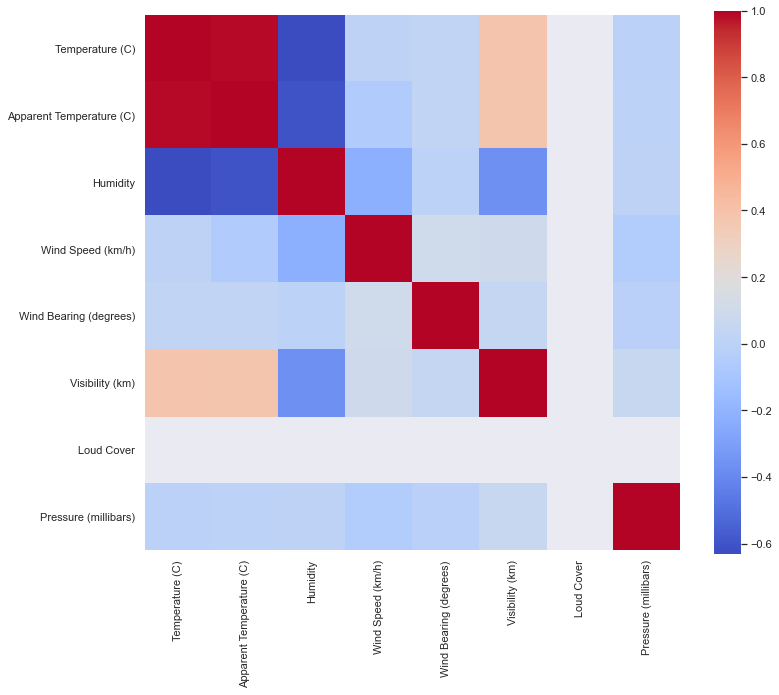

```python
correlation = data.corr()
plt.subplots(figsize=(12, 10))
sns.set(font_scale=1)
sns.heatmap(correlation, square=True,cmap='coolwarm');
```

#### Try to visualize strong correlated data with Pair Plot

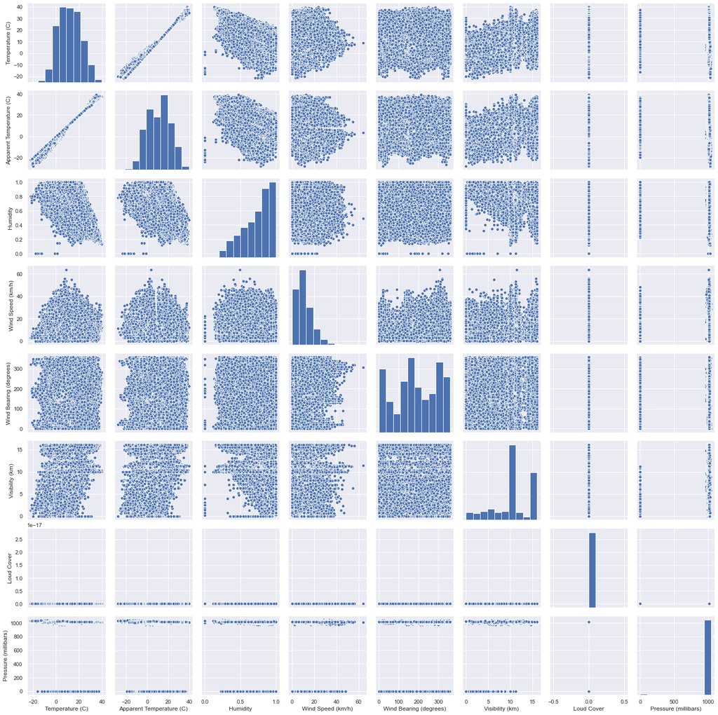

```python
sns.pairplot(data, height = 2.5)
plt.show();
```

## Relation Between Two Attributes

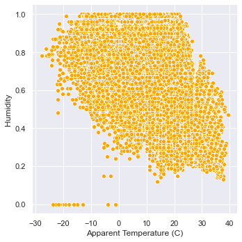

```python
sns.relplot(data = data, x = "Apparent Temperature (C)", y = "Humidity", color = 'orange')
```

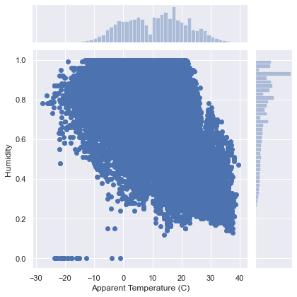

```python
sns.jointplot(data = data, x = "Apparent Temperature (C)", y = "Humidity")
```

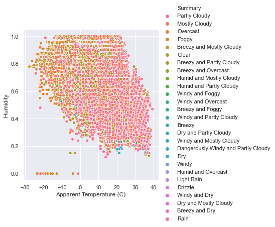

```python
sns.relplot(data=data,x="Apparent Temperature (C)",y="Humidity",color="purple",hue="Summary")
```

## Plotting Variation in Apparent Temperature and Humidity with time

```python
data_columns = ['Apparent Temperature (C)', 'Humidity']
data_monthly_mean = data[data_columns].resample('MS').mean()
data_monthly_mean.head()
```

| Formatted Date | Apparent Temperature (C) | Humidity |
| --- | --- | --- |
| 2005-12-01 00:00:00+00:00 | -4.050000 | 0.890000 |
| 2006-01-01 00:00:00+00:00 | -4.173708 | 0.834610 |
| 2006-02-01 00:00:00+00:00 | -2.990716 | 0.843467 |
| 2006-03-01 00:00:00+00:00 | 1.969780 | 0.778737 |
| 2006-04-01 00:00:00+00:00 | 12.098827 | 0.728625 |

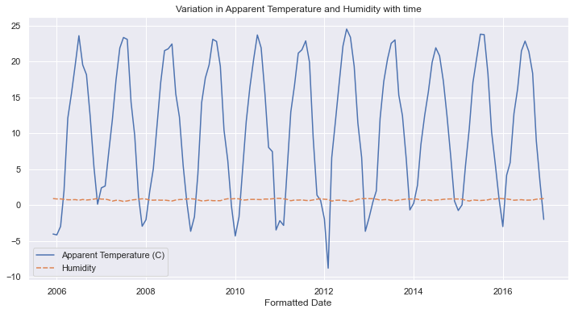

```python
plt.figure(figsize=(12,6))
plt.title("Variation in Apparent Temperature and Humidity with time")
sns.lineplot(data=data_monthly_mean)
```

We can see that humidity remained almost constant in these 10 years. Also the average apparent temperature is almost same.

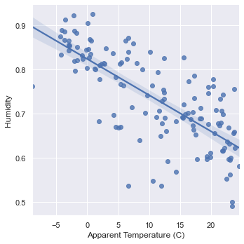

```python
sns.lmplot(x='Apparent Temperature (C)',y='Humidity',data=data_monthly_mean)
plt.show()
```

Lm plot or reg plot is a statistical method for predictive analysis. Apparent temperature V/s Humidity

## Data of a particular month from every year

```python
data_March = data_monthly_mean[data_monthly_mean.index.month==3]
data_March
```

| Formatted Date | Apparent Temperature (C) | Humidity |
| --- | --- | --- |
| 2006-03-01 00:00:00+00:00 | 1.969780 | 0.778737 |
| 2007-03-01 00:00:00+00:00 | 7.174619 | 0.713884 |
| 2008-03-01 00:00:00+00:00 | 5.004353 | 0.668468 |
| 2009-03-01 00:00:00+00:00 | 4.280585 | 0.696680 |
| 2010-03-01 00:00:00+00:00 | 4.589038 | 0.670161 |
| 2011-03-01 00:00:00+00:00 | 4.589785 | 0.782970 |
| 2012-03-01 00:00:00+00:00 | 6.591502 | 0.535941 |
| 2013-03-01 00:00:00+00:00 | 1.957445 | 0.809946 |
| 2014-03-01 00:00:00+00:00 | 8.408303 | 0.640403 |
| 2015-03-01 00:00:00+00:00 | 5.441592 | 0.669476 |
| 2016-03-01 00:00:00+00:00 | 5.901404 | 0.764677 |

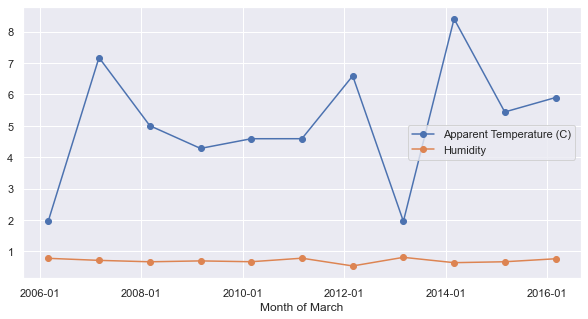

```python
import matplotlib.dates as mdates
from datetime import datetime
fig, ax = plt.subplots(figsize=(10,5))
ax.plot(data_March.loc['2006-03-01':'2016-03-01', 'Apparent Temperature (C)'], marker='o', linestyle='-',label='Apparent Temperature (C)')
ax.plot(data_March.loc['2006-03-01':'2016-03-01', 'Humidity'], marker='o', linestyle='-',label='Humidity')
ax.xaxis.set_major_formatter(mdates.DateFormatter('%Y-%m'))
ax.legend(loc = 'center right')
ax.set_xlabel('Month of March')
```

## Delete Loud Cover Attribute

```python
data['Loud Cover'].value_counts()
```

```
0.0    96453
Name: Loud Cover, dtype: int64
```

We can see that in data dafinition, **Loud Cover** has only same value 0 in all data. So we simply delete that attribute.

```python
data.drop(['Loud Cover'],axis=1,inplace=True)
data.head()
```

| Formatted Date | Summary | Precip Type | Temperature (C) | Apparent Temperature (C) | Humidity | Wind Speed (km/h) | Wind Bearing (degrees) | Visibility (km) | Pressure (millibars) | Daily Summary |
| --- | --- | --- | --- | --- | --- | --- | --- | --- | --- | --- |
| 2006-03-31 22:00:00+00:00 | Partly Cloudy | rain | 9.472222 | 7.388889 | 0.89 | 14.1197 | 251.0 | 15.8263 | 1015.13 | Partly cloudy throughout the day. |
| 2006-03-31 23:00:00+00:00 | Partly Cloudy | rain | 9.355556 | 7.227778 | 0.86 | 14.2646 | 259.0 | 15.8263 | 1015.63 | Partly cloudy throughout the day. |
| 2006-04-01 00:00:00+00:00 | Mostly Cloudy | rain | 9.377778 | 9.377778 | 0.89 | 3.9284 | 204.0 | 14.9569 | 1015.94 | Partly cloudy throughout the day. |
| 2006-04-01 01:00:00+00:00 | Partly Cloudy | rain | 8.288889 | 5.944444 | 0.83 | 14.1036 | 269.0 | 15.8263 | 1016.41 | Partly cloudy throughout the day. |
| 2006-04-01 02:00:00+00:00 | Mostly Cloudy | rain | 8.755556 | 6.977778 | 0.83 | 11.0446 | 259.0 | 15.8263 | 1016.51 | Partly cloudy throughout the day. |

## Check missing values in Dataset

```python
for var in data.columns:
    print(str(var) +": \t"+ str(data[var].isnull().sum()))
```

```
Summary: 	0
Precip Type: 	517
Temperature (C): 	0
Apparent Temperature (C): 	0
Humidity: 	0
Wind Speed (km/h): 	0
Wind Bearing (degrees): 	0
Visibility (km): 	0
Pressure (millibars): 	0
Daily Summary: 	0
```

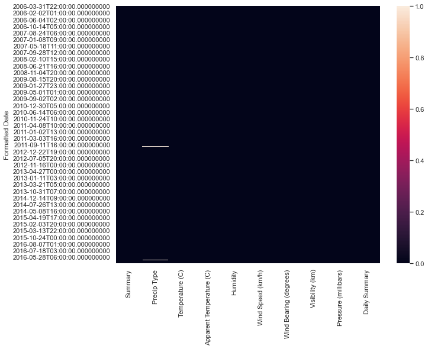

```python
plt.subplots(figsize=(10, 8))
sns.heatmap(data.isnull())
```

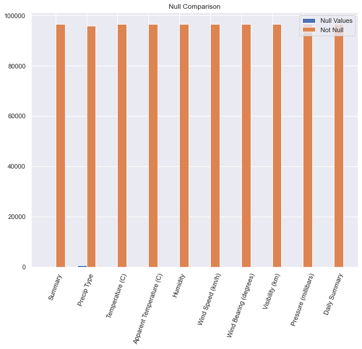

```python
plt.subplots(figsize=(10, 8))
pos = np.arange(len(data.columns))
width = 0.3
plt.bar(pos - width / 2, data.isnull().sum(), width, label='Null Values')
plt.bar(pos + width / 2, data.notnull().sum(), width, label='Not Null')

plt.xticks(pos, rotation=70)
ax = plt.gca()
ax.set_xticklabels(data.columns)

plt.title('Null Comparison')
plt.legend()
plt.show()
```

## Fill Out Missing Values in Precip Type

We have almost 96000 Data, so only 500 missing values of **Precip Type** is not a big deal. We can fil with different methods. First we inspect the **Precip Type**.

```python
data['Precip Type'].value_counts()
```

```
rain    85224
snow    10712
Name: Precip Type, dtype: int64
```

```
<BarContainer object of 2 artists>
```

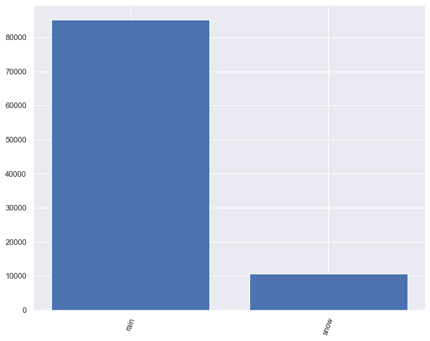

```python
plt.subplots(figsize=(10, 8))
plt.xticks(rotation=70)
plt.bar(data['Precip Type'].value_counts().index, ((data['Precip Type'].value_counts().values)))
```

### Check the mode value and fill NaN with that.

Because rain has the most value if we compare with snow.

```python
data['Precip Type'].fillna(data['Precip Type'].mode()[0],inplace = True)
```

```python
for var in data.columns:
    print(str(var) +": \t"+ str(data[var].isnull().sum()))
```

```
Summary: 	0
Precip Type: 	0
Temperature (C): 	0
Apparent Temperature (C): 	0
Humidity: 	0
Wind Speed (km/h): 	0
Wind Bearing (degrees): 	0
Visibility (km): 	0
Pressure (millibars): 	0
Daily Summary: 	0
```

Now our data set 0 NaN value. So lets move to next step.

## Check 0s in Dataset

```python
for var in data.columns:
    print(str(var) +": \t"+ str(len(data[data[var] == 0])))
```

```
Summary: 	0
Precip Type: 	0
Temperature (C): 	325
Apparent Temperature (C): 	69
Humidity: 	22
Wind Speed (km/h): 	1297
Wind Bearing (degrees): 	2264
Visibility (km): 	450
Pressure (millibars): 	1288
Daily Summary: 	0
```

```python
data.describe()
```

|  | Temperature (C) | Apparent Temperature (C) | Humidity | Wind Speed (km/h) | Wind Bearing (degrees) | Visibility (km) | Pressure (millibars) |
| --- | --- | --- | --- | --- | --- | --- | --- |
| count | 96453.000000 | 96453.000000 | 96453.000000 | 96453.000000 | 96453.000000 | 96453.000000 | 96453.000000 |
| mean | 11.932678 | 10.855029 | 0.734899 | 10.810640 | 187.509232 | 10.347325 | 1003.235956 |
| std | 9.551546 | 10.696847 | 0.195473 | 6.913571 | 107.383428 | 4.192123 | 116.969906 |
| min | -21.822222 | -27.716667 | 0.000000 | 0.000000 | 0.000000 | 0.000000 | 0.000000 |
| 25% | 4.688889 | 2.311111 | 0.600000 | 5.828200 | 116.000000 | 8.339800 | 1011.900000 |
| 50% | 12.000000 | 12.000000 | 0.780000 | 9.965900 | 180.000000 | 10.046400 | 1016.450000 |
| 75% | 18.838889 | 18.838889 | 0.890000 | 14.135800 | 290.000000 | 14.812000 | 1021.090000 |
| max | 39.905556 | 39.344444 | 1.000000 | 63.852600 | 359.000000 | 16.100000 | 1046.380000 |

#### All attributes of Weather can have 0, except Pressure. I am afraid that it can be suppose to be null value in Pressure Attribute

### Handling Pressure Attribute 0s values

```python
data['Pressure (millibars)'].replace(0,np.NaN,inplace=True)
```

```python
data.info()
```

```
<class 'pandas.core.frame.DataFrame'>
DatetimeIndex: 96453 entries, 2006-03-31 22:00:00+00:00 to 2016-09-09 21:00:00+00:00
Data columns (total 10 columns):
 #   Column                    Non-Null Count  Dtype
---  ------                    --------------  -----
 0   Summary                   96453 non-null  object
 1   Precip Type               96453 non-null  object
 2   Temperature (C)           96453 non-null  float64
 3   Apparent Temperature (C)  96453 non-null  float64
 4   Humidity                  96453 non-null  float64
 5   Wind Speed (km/h)         96453 non-null  float64
 6   Wind Bearing (degrees)    96453 non-null  float64
 7   Visibility (km)           96453 non-null  float64
 8   Pressure (millibars)      95165 non-null  float64
 9   Daily Summary             96453 non-null  object
dtypes: float64(7), object(3)
memory usage: 10.6+ MB
```

```python
for var in data.columns:
    print(str(var) +": \t"+ str(data[var].isnull().sum()))
```

```
Summary: 	0
Precip Type: 	0
Temperature (C): 	0
Apparent Temperature (C): 	0
Humidity: 	0
Wind Speed (km/h): 	0
Wind Bearing (degrees): 	0
Visibility (km): 	0
Pressure (millibars): 	1288
Daily Summary: 	0
```

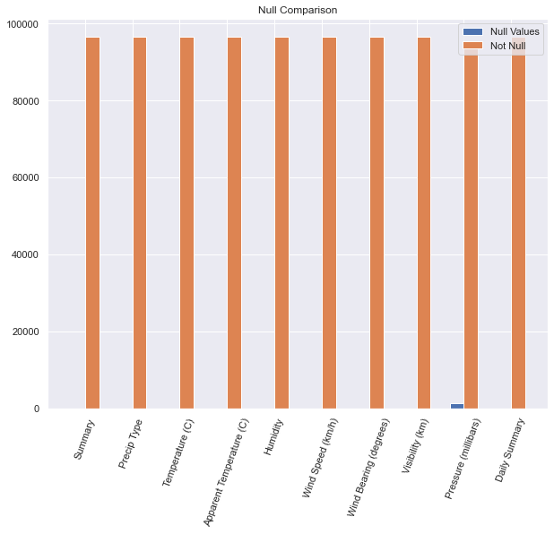

```python
plt.subplots(figsize=(10, 8))
pos = np.arange(len(data.columns))
width = 0.3
plt.bar(pos - width / 2, data.isnull().sum(), width, label='Null Values')
plt.bar(pos + width / 2, data.notnull().sum(), width, label='Not Null')

plt.xticks(pos, rotation=70)
ax = plt.gca()
ax.set_xticklabels(data.columns)

plt.title('Null Comparison')
plt.legend()
plt.show()
```

#### We simply use mean method to fill those missing values in Pressure

```python
data['Pressure (millibars)'].fillna(data['Pressure (millibars)'].mean(),inplace=True)
data.info()
```

```
<class 'pandas.core.frame.DataFrame'>
DatetimeIndex: 96453 entries, 2006-03-31 22:00:00+00:00 to 2016-09-09 21:00:00+00:00
Data columns (total 10 columns):
 #   Column                    Non-Null Count  Dtype
---  ------                    --------------  -----
 0   Summary                   96453 non-null  object
 1   Precip Type               96453 non-null  object
 2   Temperature (C)           96453 non-null  float64
 3   Apparent Temperature (C)  96453 non-null  float64
 4   Humidity                  96453 non-null  float64
 5   Wind Speed (km/h)         96453 non-null  float64
 6   Wind Bearing (degrees)    96453 non-null  float64
 7   Visibility (km)           96453 non-null  float64
 8   Pressure (millibars)      96453 non-null  float64
 9   Daily Summary             96453 non-null  object
dtypes: float64(7), object(3)
memory usage: 10.6+ MB
```

```python
data.describe()
```

|  | Temperature (C) | Apparent Temperature (C) | Humidity | Wind Speed (km/h) | Wind Bearing (degrees) | Visibility (km) | Pressure (millibars) |
| --- | --- | --- | --- | --- | --- | --- | --- |
| count | 96453.000000 | 96453.000000 | 96453.000000 | 96453.000000 | 96453.000000 | 96453.000000 | 96453.000000 |
| mean | 11.932678 | 10.855029 | 0.734899 | 10.810640 | 187.509232 | 10.347325 | 1016.814140 |
| std | 9.551546 | 10.696847 | 0.195473 | 6.913571 | 107.383428 | 4.192123 | 7.726246 |
| min | -21.822222 | -27.716667 | 0.000000 | 0.000000 | 0.000000 | 0.000000 | 973.780000 |
| 25% | 4.688889 | 2.311111 | 0.600000 | 5.828200 | 116.000000 | 8.339800 | 1012.200000 |
| 50% | 12.000000 | 12.000000 | 0.780000 | 9.965900 | 180.000000 | 10.046400 | 1016.670000 |
| 75% | 18.838889 | 18.838889 | 0.890000 | 14.135800 | 290.000000 | 14.812000 | 1021.090000 |
| max | 39.905556 | 39.344444 | 1.000000 | 63.852600 | 359.000000 | 16.100000 | 1046.380000 |

## Checking Outliers

#### 1- Temperature (C)

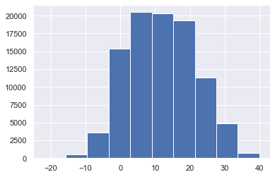

```python
data['Temperature (C)'].hist()
```

The **Temperature (C)** data is in normal distribution.

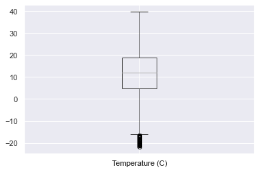

```python
data[['Temperature (C)']].boxplot()
```

We can some data appear to be outliers here. But if we see the histogram, our data is consistent. Se we dont suppose to be that data as outliers.

#### 2- Apparent Temperature (C)

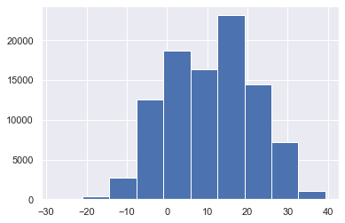

```python
data['Apparent Temperature (C)'].hist()
```

The **Apparent Temperature (C)** data is in normal distribution.

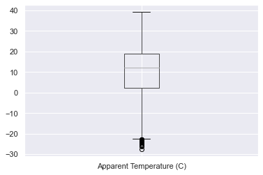

```python
data[['Apparent Temperature (C)']].boxplot()
```

Again we can some data appear to be outliers here but these data are close to the range and if we see the histogram, our data is consistent. Se we dont suppose to be that data as outliers.

#### 3- Humidity

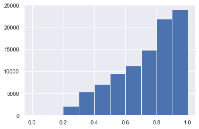

```python
data['Humidity'].hist()
```

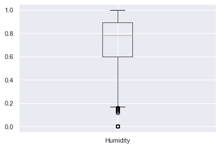

```python
data[['Humidity']].boxplot()
```

Humadity data is in normalized form so data is in the range from 0 to 1 and no data is out of the range. So we can say there are no outliers here.

#### Humidity data is in skewed distribution. So we try to group them by Use Binning. At the time of applyingmachine learning, we will use both attribute to check accuracy of the model.

```python
data['Binned_Humidity'] = pd.cut(data['Humidity'],bins=[0,0.40,0.90,1],labels=[1,2,3])
```

```python
data.head()
```

| Formatted Date | Summary | Precip Type | Temperature (C) | Apparent Temperature (C) | Humidity | Wind Speed (km/h) | Wind Bearing (degrees) | Visibility (km) | Pressure (millibars) | Daily Summary | Binned_Humidity |
| --- | --- | --- | --- | --- | --- | --- | --- | --- | --- | --- | --- |
| 2006-03-31 22:00:00+00:00 | Partly Cloudy | rain | 9.472222 | 7.388889 | 0.89 | 14.1197 | 251.0 | 15.8263 | 1015.13 | Partly cloudy throughout the day. | 2 |
| 2006-03-31 23:00:00+00:00 | Partly Cloudy | rain | 9.355556 | 7.227778 | 0.86 | 14.2646 | 259.0 | 15.8263 | 1015.63 | Partly cloudy throughout the day. | 2 |
| 2006-04-01 00:00:00+00:00 | Mostly Cloudy | rain | 9.377778 | 9.377778 | 0.89 | 3.9284 | 204.0 | 14.9569 | 1015.94 | Partly cloudy throughout the day. | 2 |
| 2006-04-01 01:00:00+00:00 | Partly Cloudy | rain | 8.288889 | 5.944444 | 0.83 | 14.1036 | 269.0 | 15.8263 | 1016.41 | Partly cloudy throughout the day. | 2 |
| 2006-04-01 02:00:00+00:00 | Mostly Cloudy | rain | 8.755556 | 6.977778 | 0.83 | 11.0446 | 259.0 | 15.8263 | 1016.51 | Partly cloudy throughout the day. | 2 |

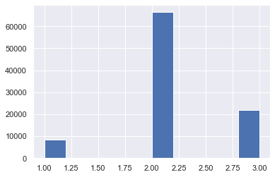

```python
data['Binned_Humidity'].hist()
```

#### After Binning, We can have some Null values in that binned column so we simply use forward fill methd.

```python
data['Binned_Humidity'].isnull().sum()
```

```
22
```

```python
data['Binned_Humidity'].fillna(method = 'ffill',inplace = True)
data['Binned_Humidity'].isnull().sum()
```

```
0
```

#### 4- Wind Speed (km/h)

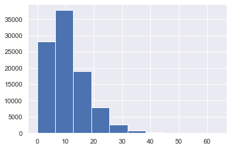

```python
data['Wind Speed (km/h)'].hist()
```

The **Wind Speed** data is in skewed distribution.

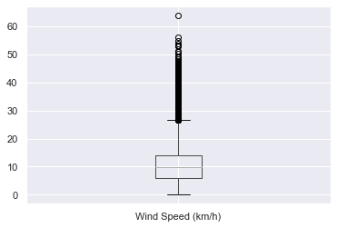

```python
data[['Wind Speed (km/h)']].boxplot()
```

Some data is shown to be Outlier here and also, this attribute data is in skewed distribution. So we group them by using **binning**.

```python
data['Binned_Wind_Speed_(km/h)'] = pd.cut(data['Wind Speed (km/h)'],bins=[0,5,20,50],labels=[1,2,3])
```

```python
data.head()
```

| Formatted Date | Summary | Precip Type | Temperature (C) | Apparent Temperature (C) | Humidity | Wind Speed (km/h) | Wind Bearing (degrees) | Visibility (km) | Pressure (millibars) | Daily Summary | Binned_Humidity | Binned_Wind_Speed_(km/h) |
| --- | --- | --- | --- | --- | --- | --- | --- | --- | --- | --- | --- | --- |
| 2006-03-31 22:00:00+00:00 | Partly Cloudy | rain | 9.472222 | 7.388889 | 0.89 | 14.1197 | 251.0 | 15.8263 | 1015.13 | Partly cloudy throughout the day. | 2 | 2 |
| 2006-03-31 23:00:00+00:00 | Partly Cloudy | rain | 9.355556 | 7.227778 | 0.86 | 14.2646 | 259.0 | 15.8263 | 1015.63 | Partly cloudy throughout the day. | 2 | 2 |
| 2006-04-01 00:00:00+00:00 | Mostly Cloudy | rain | 9.377778 | 9.377778 | 0.89 | 3.9284 | 204.0 | 14.9569 | 1015.94 | Partly cloudy throughout the day. | 2 | 1 |
| 2006-04-01 01:00:00+00:00 | Partly Cloudy | rain | 8.288889 | 5.944444 | 0.83 | 14.1036 | 269.0 | 15.8263 | 1016.41 | Partly cloudy throughout the day. | 2 | 2 |
| 2006-04-01 02:00:00+00:00 | Mostly Cloudy | rain | 8.755556 | 6.977778 | 0.83 | 11.0446 | 259.0 | 15.8263 | 1016.51 | Partly cloudy throughout the day. | 2 | 2 |

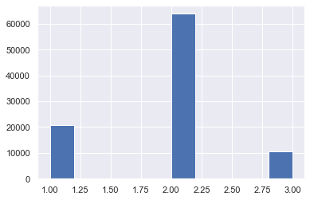

```python
data['Binned_Wind_Speed_(km/h)'].hist()
```

#### After Binning, We can have some Null values in that binned column so we simply use forward fill methd.

```python
data['Binned_Wind_Speed_(km/h)'].isnull().sum()
```

```
1308
```

```python
data['Binned_Wind_Speed_(km/h)'].fillna(method = 'ffill',inplace = True)
data['Binned_Wind_Speed_(km/h)'].isnull().sum()
```

```
0
```

#### 5- Wind Bearing (degrees)

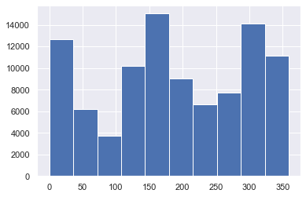

```python
data['Wind Bearing (degrees)'].hist()
```

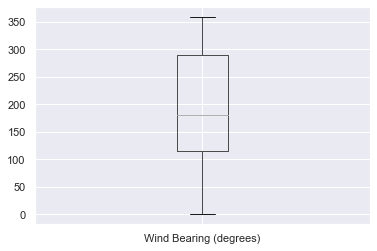

```python
data[['Wind Bearing (degrees)']].boxplot()
```

There is no Outlier here, but data is not in normal distribution. But the data is in 360 degree form. So we dont group them. Although we can but may be data will be overfit. Later on we will try to group that attribute to check the effect on result.

#### 6- Visibility (km)

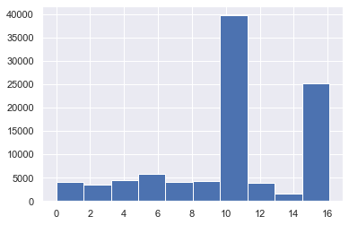

```python
data['Visibility (km)'].hist()
```

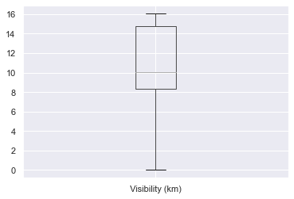

```python
data[['Visibility (km)']].boxplot()
```

#### 7- Pressure (millibars)

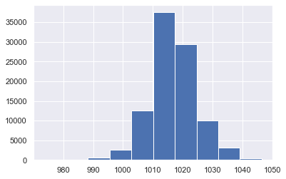

```python
data['Pressure (millibars)'].hist()
```

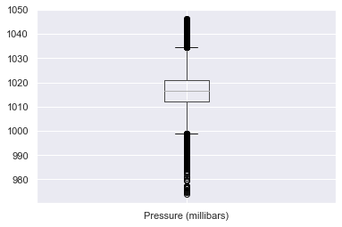

```python
data[['Pressure (millibars)']].boxplot()
```

## Handle Object Values

```python
for var in data.columns:
    if (data[var].dtype) == object:
        print(str(var) +": \t"+ str((data[var].dtype)))
```

```
Summary: 	object
Precip Type: 	object
Daily Summary: 	object
```

#### We have 3 attributes of object data types in which summary and Daily Summary seems to be similar so we try to figure out the insights.

```python
data['Summary'].value_counts()
```

```
Partly Cloudy                          31733
Mostly Cloudy                          28094
Overcast                               16597
Clear                                  10890
Foggy                                   7148
Breezy and Overcast                      528
Breezy and Mostly Cloudy                 516
Breezy and Partly Cloudy                 386
Dry and Partly Cloudy                     86
Windy and Partly Cloudy                   67
Light Rain                                63
Breezy                                    54
Windy and Overcast                        45
Humid and Mostly Cloudy                   40
Drizzle                                   39
Windy and Mostly Cloudy                   35
Breezy and Foggy                          35
Dry                                       34
Humid and Partly Cloudy                   17
Dry and Mostly Cloudy                     14
Rain                                      10
Windy                                      8
Humid and Overcast                         7
Windy and Foggy                            4
Dangerously Windy and Partly Cloudy        1
Breezy and Dry                             1
Windy and Dry                              1
Name: Summary, dtype: int64
```

```python
data['Daily Summary'].value_counts()
```

```
Mostly cloudy throughout the day.                                                 20085
Partly cloudy throughout the day.                                                  9981
Partly cloudy until night.                                                         6169
Partly cloudy starting in the morning.                                             5184
Foggy in the morning.                                                              4201
                                                                                  ...
Mostly cloudy starting in the morning and breezy in the evening.                     24
Mostly cloudy starting in the morning continuing until afternoon.                    24
Light rain until morning.                                                            24
Rain until afternoon.                                                                24
Foggy starting overnight continuing until morning and breezy in the afternoon.       23
Name: Daily Summary, Length: 214, dtype: int64
```

#### "Daily Summary" attribute is discription of the weather which is summarized in "Summry", so i think, we should delete that attribute.

```python
data.drop(['Daily Summary'],axis=1,inplace=True)
data.head()
```

| Formatted Date | Summary | Precip Type | Temperature (C) | Apparent Temperature (C) | Humidity | Wind Speed (km/h) | Wind Bearing (degrees) | Visibility (km) | Pressure (millibars) | Binned_Humidity | Binned_Wind_Speed_(km/h) |
| --- | --- | --- | --- | --- | --- | --- | --- | --- | --- | --- | --- |
| 2006-03-31 22:00:00+00:00 | Partly Cloudy | rain | 9.472222 | 7.388889 | 0.89 | 14.1197 | 251.0 | 15.8263 | 1015.13 | 2 | 2 |
| 2006-03-31 23:00:00+00:00 | Partly Cloudy | rain | 9.355556 | 7.227778 | 0.86 | 14.2646 | 259.0 | 15.8263 | 1015.63 | 2 | 2 |
| 2006-04-01 00:00:00+00:00 | Mostly Cloudy | rain | 9.377778 | 9.377778 | 0.89 | 3.9284 | 204.0 | 14.9569 | 1015.94 | 2 | 1 |
| 2006-04-01 01:00:00+00:00 | Partly Cloudy | rain | 8.288889 | 5.944444 | 0.83 | 14.1036 | 269.0 | 15.8263 | 1016.41 | 2 | 2 |
| 2006-04-01 02:00:00+00:00 | Mostly Cloudy | rain | 8.755556 | 6.977778 | 0.83 | 11.0446 | 259.0 | 15.8263 | 1016.51 | 2 | 2 |

```python
for var in data.columns:
    if (data[var].dtype) == object:
        print(str(var) +": \t"+ str((data[var].dtype)))
```

```
Summary: 	object
Precip Type: 	object
```

Now we have two object attributes and both can be our target class. First we try to convert them into numeric data type.  
So we have two methods to change the data into numeric form  
**1- Dummy Encoding or One-Hot Encoding**  
**2- Pandas Categorical Codes**  
First we use Pandas Categorcial Codes and save it in another dataframe.

## Pandas Categorical Codes

```python
df1 = pd.DataFrame(data)
df1
```

| Formatted Date | Summary | Precip Type | Temperature (C) | Apparent Temperature (C) | Humidity | Wind Speed (km/h) | Wind Bearing (degrees) | Visibility (km) | Pressure (millibars) | Binned_Humidity | Binned_Wind_Speed_(km/h) |
| --- | --- | --- | --- | --- | --- | --- | --- | --- | --- | --- | --- |
| 2006-03-31 22:00:00+00:00 | Partly Cloudy | rain | 9.472222 | 7.388889 | 0.89 | 14.1197 | 251.0 | 15.8263 | 1015.13 | 2 | 2 |
| 2006-03-31 23:00:00+00:00 | Partly Cloudy | rain | 9.355556 | 7.227778 | 0.86 | 14.2646 | 259.0 | 15.8263 | 1015.63 | 2 | 2 |
| 2006-04-01 00:00:00+00:00 | Mostly Cloudy | rain | 9.377778 | 9.377778 | 0.89 | 3.9284 | 204.0 | 14.9569 | 1015.94 | 2 | 1 |
| 2006-04-01 01:00:00+00:00 | Partly Cloudy | rain | 8.288889 | 5.944444 | 0.83 | 14.1036 | 269.0 | 15.8263 | 1016.41 | 2 | 2 |
| 2006-04-01 02:00:00+00:00 | Mostly Cloudy | rain | 8.755556 | 6.977778 | 0.83 | 11.0446 | 259.0 | 15.8263 | 1016.51 | 2 | 2 |
| ... | ... | ... | ... | ... | ... | ... | ... | ... | ... | ... | ... |
| 2016-09-09 17:00:00+00:00 | Partly Cloudy | rain | 26.016667 | 26.016667 | 0.43 | 10.9963 | 31.0 | 16.1000 | 1014.36 | 2 | 2 |
| 2016-09-09 18:00:00+00:00 | Partly Cloudy | rain | 24.583333 | 24.583333 | 0.48 | 10.0947 | 20.0 | 15.5526 | 1015.16 | 2 | 2 |
| 2016-09-09 19:00:00+00:00 | Partly Cloudy | rain | 22.038889 | 22.038889 | 0.56 | 8.9838 | 30.0 | 16.1000 | 1015.66 | 2 | 2 |
| 2016-09-09 20:00:00+00:00 | Partly Cloudy | rain | 21.522222 | 21.522222 | 0.60 | 10.5294 | 20.0 | 16.1000 | 1015.95 | 2 | 2 |
| 2016-09-09 21:00:00+00:00 | Partly Cloudy | rain | 20.438889 | 20.438889 | 0.61 | 5.8765 | 39.0 | 15.5204 | 1016.16 | 2 | 2 |

96453 rows × 11 columns

```python
df1.info()
```

```
<class 'pandas.core.frame.DataFrame'>
DatetimeIndex: 96453 entries, 2006-03-31 22:00:00+00:00 to 2016-09-09 21:00:00+00:00
Data columns (total 11 columns):
 #   Column                    Non-Null Count  Dtype
---  ------                    --------------  -----
 0   Summary                   96453 non-null  object
 1   Precip Type               96453 non-null  object
 2   Temperature (C)           96453 non-null  float64
 3   Apparent Temperature (C)  96453 non-null  float64
 4   Humidity                  96453 non-null  float64
 5   Wind Speed (km/h)         96453 non-null  float64
 6   Wind Bearing (degrees)    96453 non-null  float64
 7   Visibility (km)           96453 non-null  float64
 8   Pressure (millibars)      96453 non-null  float64
 9   Binned_Humidity           96453 non-null  category
 10  Binned_Wind_Speed_(km/h)  96453 non-null  category
dtypes: category(2), float64(7), object(2)
memory usage: 10.0+ MB
```

### Summary

```python
df1['Summary'].value_counts()
```

```
Partly Cloudy                          31733
Mostly Cloudy                          28094
Overcast                               16597
Clear                                  10890
Foggy                                   7148
Breezy and Overcast                      528
Breezy and Mostly Cloudy                 516
Breezy and Partly Cloudy                 386
Dry and Partly Cloudy                     86
Windy and Partly Cloudy                   67
Light Rain                                63
Breezy                                    54
Windy and Overcast                        45
Humid and Mostly Cloudy                   40
Drizzle                                   39
Windy and Mostly Cloudy                   35
Breezy and Foggy                          35
Dry                                       34
Humid and Partly Cloudy                   17
Dry and Mostly Cloudy                     14
Rain                                      10
Windy                                      8
Humid and Overcast                         7
Windy and Foggy                            4
Dangerously Windy and Partly Cloudy        1
Breezy and Dry                             1
Windy and Dry                              1
Name: Summary, dtype: int64
```

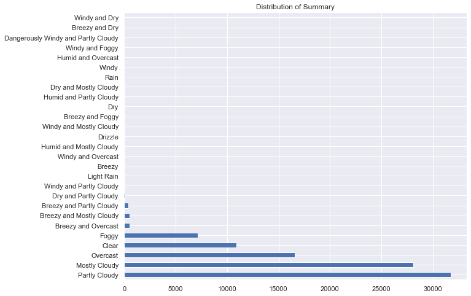

```python
plt.figure(figsize=(10,8))
plt.title('Distribution of Summary')
#df.plot(kind='barh')
df1['Summary'].value_counts().plot(kind='barh')
plt.show()
```

#### We have 27different values here, so try to mask them and minimize the unique values.

#### Masking

```python
mask = df1['Summary'].isin(df1['Summary'].value_counts()[df1['Summary'].value_counts() < 1000].index)
df1.loc[mask, 'Summary']= 'Other'
df1['Summary'].value_counts()
```

```
Partly Cloudy    31733
Mostly Cloudy    28094
Overcast         16597
Clear            10890
Foggy             7148
Other             1991
Name: Summary, dtype: int64
```

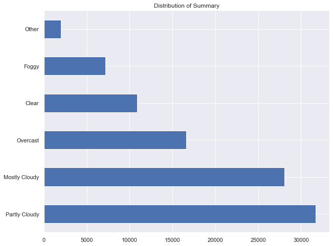

```python
plt.figure(figsize=(10,8))
plt.title('Distribution of Summary')
#df.plot(kind='barh')
df1['Summary'].value_counts().plot(kind='barh')
plt.show()
```

```python
df1['Summary'].value_counts()
```

```
Partly Cloudy    31733
Mostly Cloudy    28094
Overcast         16597
Clear            10890
Foggy             7148
Other             1991
Name: Summary, dtype: int64
```

### Precip Type

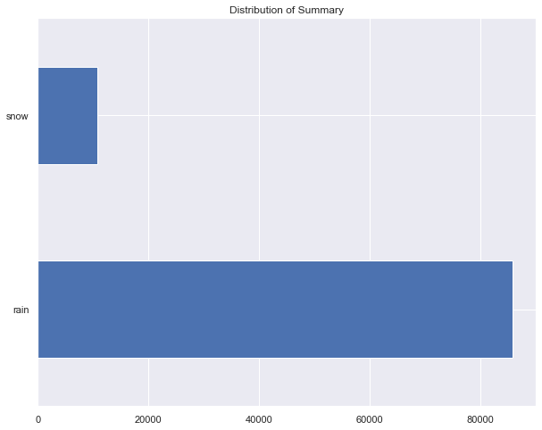

```python
plt.figure(figsize=(10,8))
plt.title('Distribution of Summary')
#df.plot(kind='barh')
df1['Precip Type'].value_counts().plot(kind='barh')
plt.show()
```

#### Now Convert Both Attrbutes to Catigorical Form

```python
df1['Summary'] = df1['Summary'].astype('category')
df1['Precip Type'] = df1['Precip Type'].astype('category')
cat_columns = ['Summary','Precip Type']
df1[cat_columns] = df1[cat_columns].apply(lambda x: x.cat.codes)
df1[cat_columns]
```

| Formatted Date | Summary | Precip Type |
| --- | --- | --- |
| 2006-03-31 22:00:00+00:00 | 5 | 0 |
| 2006-03-31 23:00:00+00:00 | 5 | 0 |
| 2006-04-01 00:00:00+00:00 | 2 | 0 |
| 2006-04-01 01:00:00+00:00 | 5 | 0 |
| 2006-04-01 02:00:00+00:00 | 2 | 0 |
| ... | ... | ... |
| 2016-09-09 17:00:00+00:00 | 5 | 0 |
| 2016-09-09 18:00:00+00:00 | 5 | 0 |
| 2016-09-09 19:00:00+00:00 | 5 | 0 |
| 2016-09-09 20:00:00+00:00 | 5 | 0 |
| 2016-09-09 21:00:00+00:00 | 5 | 0 |

96453 rows × 2 columns

```python
df1.head()
```

| Formatted Date | Summary | Precip Type | Temperature (C) | Apparent Temperature (C) | Humidity | Wind Speed (km/h) | Wind Bearing (degrees) | Visibility (km) | Pressure (millibars) | Binned_Humidity | Binned_Wind_Speed_(km/h) |
| --- | --- | --- | --- | --- | --- | --- | --- | --- | --- | --- | --- |
| 2006-03-31 22:00:00+00:00 | 5 | 0 | 9.472222 | 7.388889 | 0.89 | 14.1197 | 251.0 | 15.8263 | 1015.13 | 2 | 2 |
| 2006-03-31 23:00:00+00:00 | 5 | 0 | 9.355556 | 7.227778 | 0.86 | 14.2646 | 259.0 | 15.8263 | 1015.63 | 2 | 2 |
| 2006-04-01 00:00:00+00:00 | 2 | 0 | 9.377778 | 9.377778 | 0.89 | 3.9284 | 204.0 | 14.9569 | 1015.94 | 2 | 1 |
| 2006-04-01 01:00:00+00:00 | 5 | 0 | 8.288889 | 5.944444 | 0.83 | 14.1036 | 269.0 | 15.8263 | 1016.41 | 2 | 2 |
| 2006-04-01 02:00:00+00:00 | 2 | 0 | 8.755556 | 6.977778 | 0.83 | 11.0446 | 259.0 | 15.8263 | 1016.51 | 2 | 2 |

```python
count = 0
for var in df1.columns:
    if (df1[var].dtype) == object:
        count = count + 1
        ##print(str(var) +": \t"+ str((data[var].dtype)))
if count == 0:
    print("There is no column which have Object Data Type in df1")
else:
    print("There are " + str(count) + " which have Object Data Type")
```

```
There is no column which have Object Data Type in df1
```

#### Now we dont have any object value in df1 and data has been cleaned.